# R Practical

Ipshita Ghosh 20122006

#Libraries

```r
#for plotting
library(ggplot2)
#for splitting
library(caTools)
#for decision tree
library(rpart)
library(rpart.plot)
#timing
library(tictoc)
#ROC
library(pROC)
```

#Data

Loading the data

```r
df <- read.csv("C:\\Users\\Dell\\OneDrive\\College_2nd\\R Lab\\cia2.csv")
```

Taking a look at the dataset

```r
head(df)
```

```
##   V1 V2 V3 V4 V5 V6 V7 V8 V9      V10
## 1  x  x  x  x  o  o  x  o  o positive
## 2  x  x  x  x  o  o  o  x  o positive
## 3  x  x  x  x  o  o  o  o  x positive
## 4  x  x  x  x  o  o  o  b  b positive
## 5  x  x  x  x  o  o  b  o  b positive
## 6  x  x  x  x  o  o  b  b  o positive
```

Number of Instances: 958 (legal tic-tac-toe endgame boards)

Number of Attributes: 9, each corresponding to one tic-tac-toe square

Missing Attribute Values: None

Class Distribution: About 65.3% are positive (i.e., wins for “x”)

Attribute Information

V1 = top-left-square: {x,o,b}

V2 = top-middle-square: {x,o,b}

V3 = top-right-square: {x,o,b}

V4 = middle-left-square: {x,o,b}

V5 = middle-middle-square: {x,o,b}

V6 = middle-right-square: {x,o,b}

V7 = bottom-left-square: {x,o,b}

V8 = bottom-middle-square: {x,o,b}

V = bottom-right-square: {x,o,b}

V10 = Class: {positive,negative}

#Exploratory data Analysis

First, lets rename the data columns accordingly, for better understanding and inference

```r
names(df)[1] <- "top-left-square"
names(df)[2] <- "top-middle-square"
names(df)[3] <- "top-right-square"
names(df)[4] <- "middle-left-square"
names(df)[5] <- "middle-middle-square"
names(df)[6] <- "middle-right-square"
names(df)[7] <- "botton-left-square"
names(df)[8] <- "botton-middle-square"
names(df)[9] <- "botton-right-square"
names(df)[10] <- "class"
```

Looking at the changed dataset

```r
head(df)
```

```
##   top-left-square top-middle-square top-right-square middle-left-square
## 1               x                 x                x                  x
## 2               x                 x                x                  x
## 3               x                 x                x                  x
## 4               x                 x                x                  x
## 5               x                 x                x                  x
## 6               x                 x                x                  x
##   middle-middle-square middle-right-square botton-left-square
## 1                    o                   o                  x
## 2                    o                   o                  o
## 3                    o                   o                  o
## 4                    o                   o                  o
## 5                    o                   o                  b
## 6                    o                   o                  b
##   botton-middle-square botton-right-square    class
## 1                    o                   o positive
## 2                    x                   o positive
## 3                    o                   x positive
## 4                    b                   b positive
## 5                    o                   b positive
## 6                    b                   o positive
```

From the dataset we can understand that the data requires multivariate analysis and a decision tree is best for the case as it has different scenarios according to which the class is determined as either positive or negative

Let us look at the Class columns

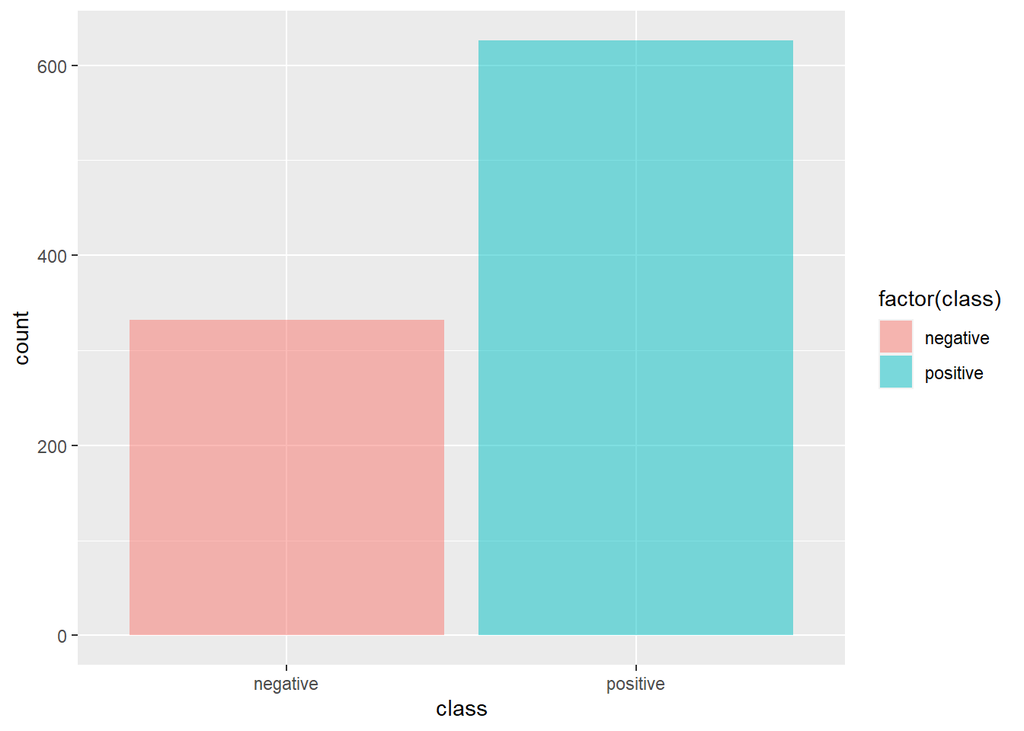

```r
ggplot(df,aes(class))+
        geom_bar(aes(fill=factor(class)),alpha=0.5)
```

#Data pre processing

```r
str(df)
```

```
## 'data.frame':    958 obs. of  10 variables:
##  $ top-left-square     : chr  "x" "x" "x" "x" ...
##  $ top-middle-square   : chr  "x" "x" "x" "x" ...
##  $ top-right-square    : chr  "x" "x" "x" "x" ...
##  $ middle-left-square  : chr  "x" "x" "x" "x" ...
##  $ middle-middle-square: chr  "o" "o" "o" "o" ...
##  $ middle-right-square : chr  "o" "o" "o" "o" ...
##  $ botton-left-square  : chr  "x" "o" "o" "o" ...
##  $ botton-middle-square: chr  "o" "x" "o" "b" ...
##  $ botton-right-square : chr  "o" "o" "x" "b" ...
##  $ class               : chr  "positive" "positive" "positive" "positive" ...
```

#Modelling

```r
set.seed(420)
split = sample.split(df$class, SplitRatio = 0.7)
train = subset(df, split == TRUE)
test = subset(df, split == FALSE)
```

Looking at the proporting in the train and test

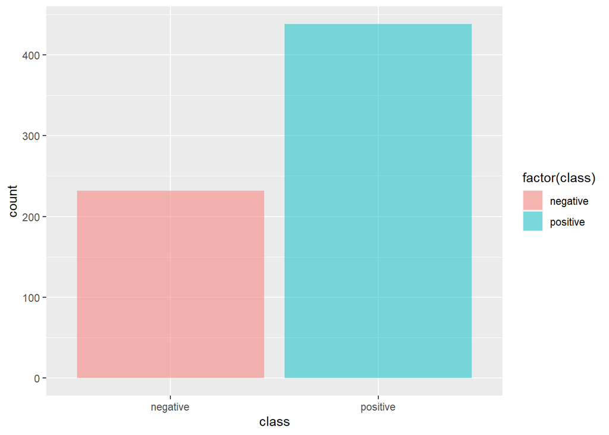

```r
par(mfrow=c(1,2))

ggplot(train, aes(class))+
        geom_bar(aes(fill=factor(class)),alpha=0.5)
```

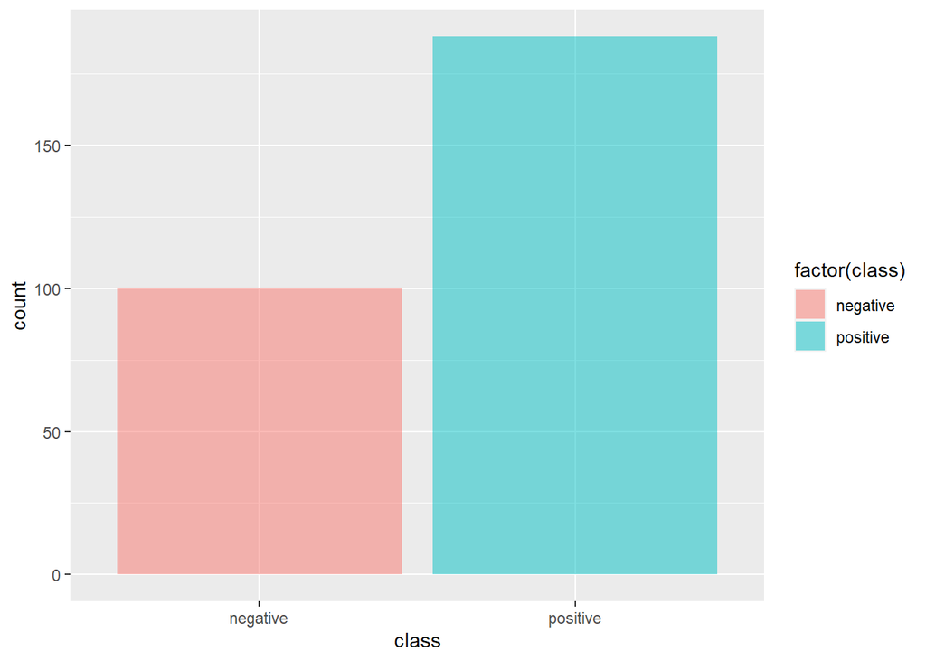

```r
ggplot(test,aes(class))+
        geom_bar(aes(fill=factor(class)),alpha=0.5)
```

From the graphs we can see that the proportion is maintained in train and test dataset, hence we can continue with the decision tree

```r
tic("Running the decision tree: ")
fit <- rpart(class~., data = train, method = 'class')
toc()
```

```
## Running the decision tree: : 0.03 sec elapsed
```

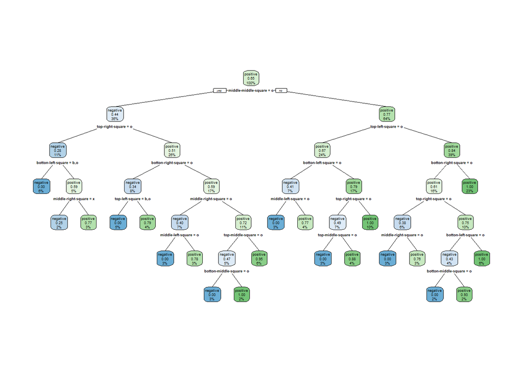

```r
rpart.plot(fit,fallen.leaves=FALSE)
```

```r
#summary(fit)
```

```r
par(mfrow=c(1,2))
rsq.rpart(fit)
```

```
##
## Classification tree:
## rpart(formula = class ~ ., data = train, method = "class")
##
## Variables actually used in tree construction:
## [1] botton-left-square   botton-middle-square botton-right-square
## [4] middle-left-square   middle-middle-square middle-right-square
## [7] top-left-square      top-middle-square    top-right-square
##
## Root node error: 232/670 = 0.34627
##
## n= 670
##
##         CP nsplit rel error  xerror     xstd
## 1 0.120690      0   1.00000 1.00000 0.053083
## 2 0.047414      1   0.87931 0.87931 0.051343
## 3 0.038793      6   0.62931 0.78017 0.049541
## 4 0.033046      8   0.55172 0.63362 0.046173
## 5 0.030172     13   0.36207 0.48707 0.041777
## 6 0.025862     18   0.20259 0.37931 0.037686
## 7 0.010000     20   0.15086 0.25862 0.031858
```

[figure not shown]

#Accuracy

```r
pred <- predict(fit, test, method = 'class')
```

```r
pred <- as.data.frame(pred)

joiner <- function(x)
{
  if(x>0.5)
  {
    return("positive")
  }
  else
  {
    return("negative")
  }
}
```

```r
tic("Prediction time: ")
pred$class <- sapply(pred$positive, joiner)
toc()
```

```
## Prediction time: : 0.02 sec elapsed
```

## Confusion Matrix

```r
confusion_m = table(test$class, pred$class)
```

## Accuracy from Confusion tree

```r
accuracy <- sum(diag(confusion_m)) / sum(confusion_m)
```

```r
 n = sum(confusion_m) # number of instances
 nc = nrow(confusion_m) # number of classes
 diag = diag(confusion_m) # number of correctly classified instances per class
 rowsums = apply(confusion_m, 1, sum) # number of instances per class
 colsums = apply(confusion_m, 2, sum) # number of predictions per class
 p = rowsums / n # distribution of instances over the actual classes
 q = colsums / n # distribution of instances over the predicted classes
```

```r
 precision = diag / colsums
 recall = diag / rowsums
 f1 = 2 * precision * recall / (precision + recall)
```

## Printing Metrics

```r
print(confusion_m)
```

```
##
##            negative positive
##   negative       90       10
##   positive        7      181
```

```r
print(paste(accuracy, "is the accuracy"))
```

```
## [1] "0.940972222222222 is the accuracy"
```

```r
print(paste(precision, "is the precision"))
```

```
## [1] "0.927835051546392 is the precision" "0.947643979057592 is the precision"
```

```r
print(paste(recall, "is the recall"))
```

```
## [1] "0.9 is the recall"               "0.962765957446808 is the recall"
```

```r
print(paste(f1, "is the f1"))
```

```
## [1] "0.913705583756345 is the f1" "0.955145118733509 is the f1"
```

# Inference

## **Basic Introduction**

For the model building, the dataset is first randomly split into two parts, one is for testing and one for training the data. Using the rpart, a large classification tree is built, which tries to predict the class of the win.

A decision, as we know, is represented upside down, which means that the first node in the tree which is $middle-middle-square$ is the root node and the most important. The nodes in the middle , i.e. nodes like $top-left-square$ are internal nodes and lastly the end of branches are the edges, in our case that is the class of the row.

## **Decision tree of our data:**

From the plot we can see that the most important decision maker for predicting the class is, $middle-middle-square$, followed by $top-right-square$ and $top-left-square$. The feature importance tells us how much a feature helped to improve the purity of all nodes. Here, the average of the classes was used, since predicting whether the game is a win or not is a classification task with two class.

To understand which features are important, $Gini-index$ is used, which means that the attributes with more gini index, makes it more important. In case of regression tree it is done using **information gain**.

The Gini index is given as follows:

$\sum \hat{p}_{mk}(1-\hat{p}_{mk})$

The sum goes from $1$ to $K$, where $K$ is the number of classes, hence in our case, it will go from 1 to 2. And $\hat{p}_{mk}$ represents the proportion of training observations in the $m^{th}$ region that are from the $k^{th}$ class.

## **Problem of Overfitting**

Since Decision trees are totally data dependant, and top down greedy, the problem of overfitting is the most problematic. The rpart library comes handy in this, as it can be used to prune the tree given a $\alpha$. In our case, we *did not face the problem of overfitting* hence pruning was not needed in our case

## **Evaluation**

The different evaluations that were done

1. accuracy -> $94.09%$ | This means that the decision tree has correctly predicted the class on the test data 94.09% of the time
2. precision -> $92.78%$ | The model gave correct predictions for a certain class for 92% of the time of 0.92 fraction of the time
3. recall -> $0.9$ | This is the fraction of instances of a class that were correctly predicted, that is 0.9
4. f1 -> $0.9137$ | This is the harmonic mean of precision and recall, and commonly reported and ranges from 0 to 9. Our f1, 9 means high performance

## **Optimization**

Hence we can say that the time complexity for decision trees is in $O(N\ kd)$

Where, $N$ = number of training examples

$k$ = number of features

$d$ = depth of the decision tree.